# Estimating the Effective Reproduction Number of COVID-19 in United Kingdom

Louis Rossouw

2020-11-07

# 1 Introduction

This paper contains estimates for the effective reproduction number $R_{t,m}$ over time $t$ in various nations and other regions $m$ of United Kingdom. This is done using the methodology as described in [1]. These have been implemented in R using `EpiEstim` package [2] which is what is used here. The methodolgy and assumptions are described in more detail [here](https://lrossouw.github.io/covid-19/estimating_r.html).

This paper and it’s results should be updated roughly daily and [is available online](https://lrossouw.github.io/covid-19/estimating_r_uk.html).

As this paper is updated over time this section will summarise significant changes. The code producing this paper is tracked using Git. The Git commit hash for this project at the time of generating this paper was 6c805b06321a24b5ca6e9bf4ad3d777a18ba8af5.

# 2 Data

Data is obtained [3]. This contains the daily cases, hospital admissions and deaths for United Kingdom by various geographies. Here the data is accessed by specimen date, admission date and date of death.

Once history is built up an allowance for rate reported cases, admissions and deaths will be made. For now the data is cut-off a week prior to the last case date in the data.

# 3 Methodology

The methodology is [described in detail here](https://lrossouw.github.io/covid-19/estimating_r.html).

# 4 Results by Nation

## 4.1 Cases, Admissions and Deaths

Below we plot cumulative case count on a log scale by nation:

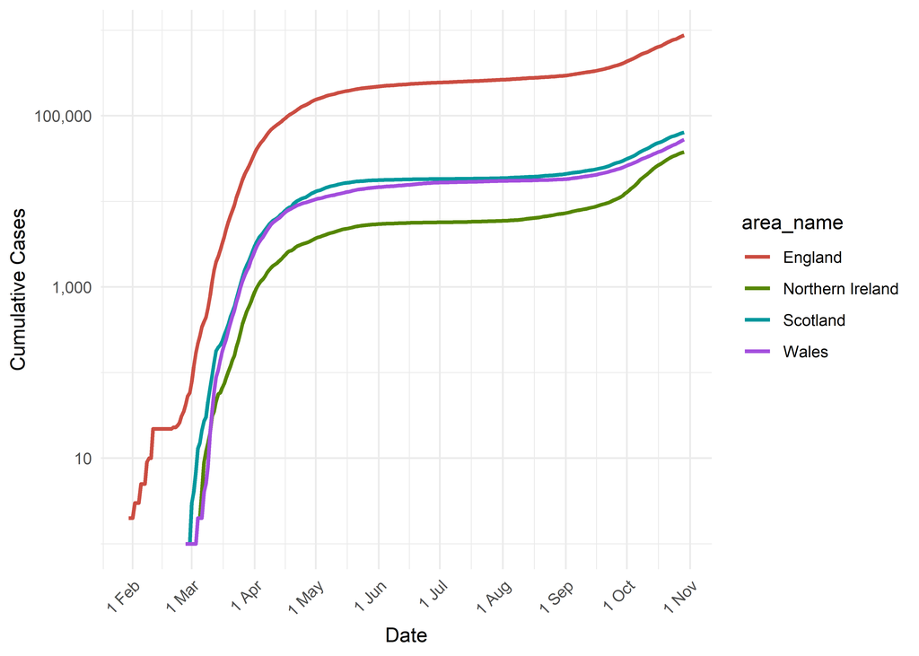

Cumulative Cases by Nation

Below we plot cumulative hospital admissions on a log scale.

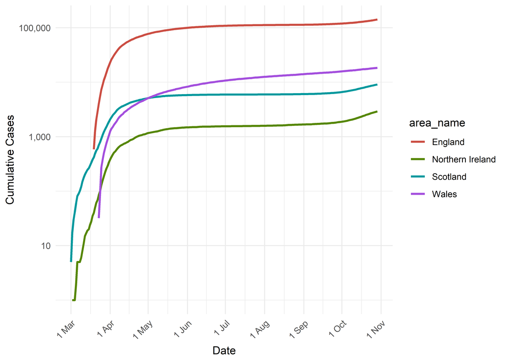

Cumulative Admissions by Nation

Below we plot the cumulative deaths by nation on a log scale:

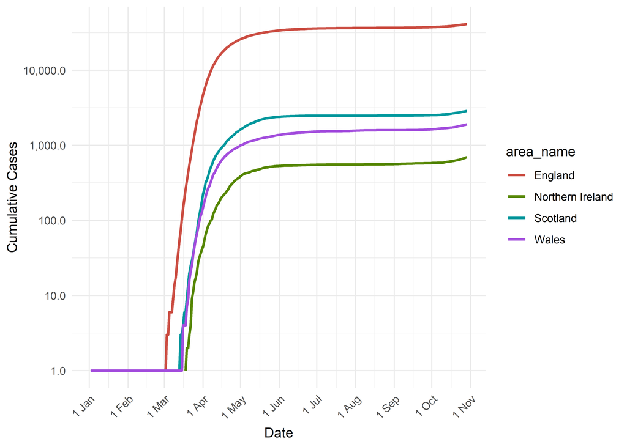

Cumulative Deaths by Nation

## 4.2 Current $R_{t,m}$ estimates by Nation

Below current (last weekly) $R_{t,m}$ estimates are tabulated.

Estimated Effective Reproduction Number by Nation

| Nation | Estimate Type | Count (Last Week) | Week Ending | R - Lower CI | R - Mean | R - Uppper CI |
| --- | --- | --- | --- | --- | --- | --- |
| England | cases | 128,133 | 2020-10-29 | 1.0 | 1.0 | 1.1 |
| England | admissions | 8,226 | 2020-10-29 | 1.2 | 1.2 | 1.3 |
| England | deaths | 1,442 | 2020-10-29 | 1.2 | 1.2 | 1.3 |
| Northern Ireland | cases | 5,635 | 2020-10-29 | 0.8 | 0.9 | 0.9 |
| Northern Ireland | admissions | 317 | 2020-10-29 | 0.9 | 1.0 | 1.1 |
| Northern Ireland | deaths | 61 | 2020-10-29 | 1.2 | 1.6 | 2.1 |
| Scotland | cases | 8,198 | 2020-10-29 | 0.9 | 0.9 | 1.0 |
| Scotland | admissions | 697 | 2020-10-29 | 0.9 | 1.0 | 1.1 |
| Scotland | deaths | 147 | 2020-10-29 | 1.1 | 1.3 | 1.5 |
| Wales | cases | 9,130 | 2020-10-29 | 1.2 | 1.2 | 1.3 |
| Wales | admissions | 658 | 2020-10-29 | 1.0 | 1.0 | 1.1 |
| Wales | deaths | 109 | 2020-10-29 | 1.2 | 1.4 | 1.7 |

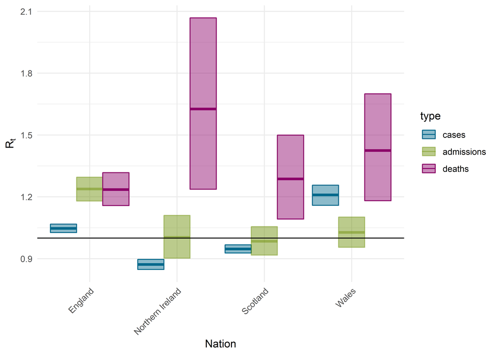

Estimated Effective Reproduction Number by Nation

## 4.3 Maps of Effective Reproduction Number

Below estimates of the reproductive number is plotted on maps of United Kingdom [4].

### 4.3.1 Cases

[interactive chart not shown]

### 4.3.2 Admissions

[interactive chart not shown]

### 4.3.3 Deaths

[interactive chart not shown]

## 4.4 Graphs over Time

Below we plot results for each nation We filter out weeks where the upper end of confidence interval for $R_{t,m}$ exceeds 4.

[1] “England”

### 4.4.1 England

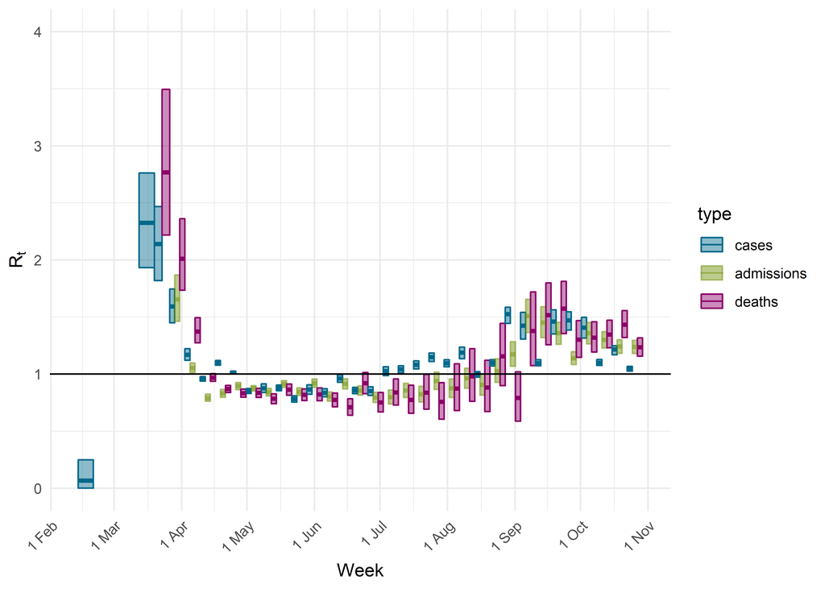

### 4.4.2 Northern Ireland

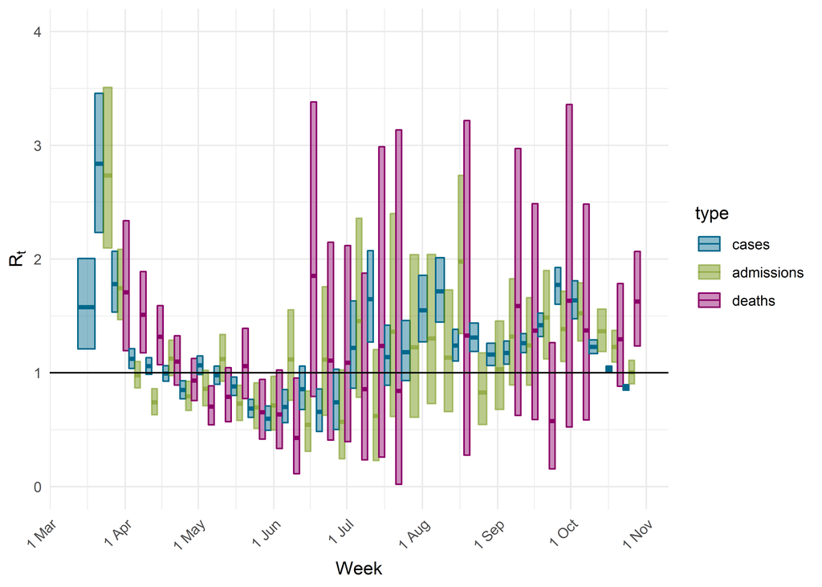

### 4.4.3 Scotland

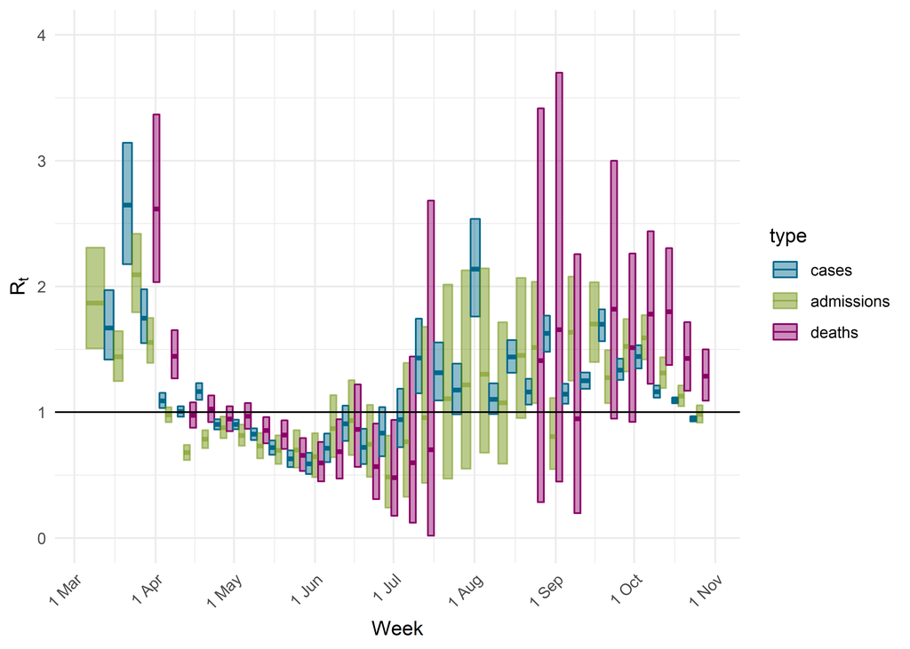

### 4.4.4 Wales

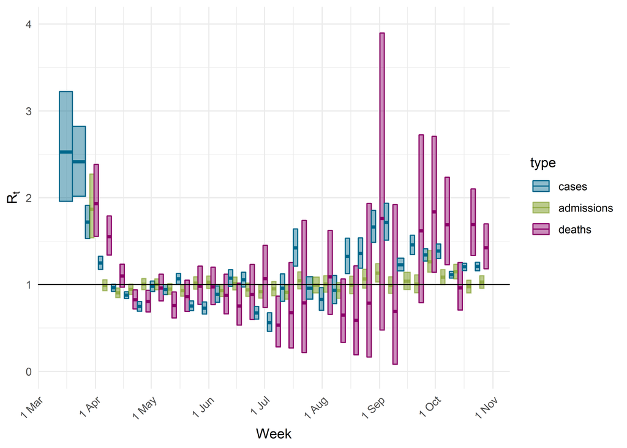

## 4.5 Detailed Results

Detailed output are saved to a comma-separated value file. The file can be found here.

# 5 Discussion

Limitation of this method to estimate $R_{t,m}$ are noted in [1]

- It’s sensitive to changes in transmissibility, changes in contact patterns, depletion of the susceptible population and control measures.
- It relies on an assumed generation interval assumptions.
- The size of the time window can affect the volatility of results.
- Results are time lagged with regards to true infection, more so in the case of the use of deaths.
- It’s sensitive to changes in case (or death) detection.
- The generation interval may change over time.

Further to the above the estimates are made under assumption that the cases and deaths are reported consistently over time. For cases this means that testing needs to be at similar levels and reported with similar lag. Should these change rapidly over an interval of a few weeks the above estimates of the effective reproduction numbers would be biased. For example a rapid expansion of testing over the last 3 weeks would results in overestimating recent effective reproduction numbers. Similarly any changes in reporting (over time and underreporting) of deaths would also bias estimates of the reproduction number estimated using deaths. It may well be that some catch-up in reported deaths is exaggerating the estimates for October.

Estimates for the reproduction number are plotted in time period in which the relevant measure is recorded. Though in reality the infections giving rise to those estimates would have occurred roughly between a week to 4 weeks earlier depending on whether it was cases or deaths. These figures have not been shifted back.

Despite these limitation we believe the ease of calculation of this method and the ability to use multiple sources makes it useful as a monitoring tool.

# 6 Author

This report was prepared by Louis Rossouw. Please get in contact with Louis Rossouw if you have comments or wish to receive this regularly.

**Louis Rossouw**  
Head of Research & Analytics  
Gen Re | Life/Health Canada, South Africa, Australia, NZ, UK & Ireland  
Email: LRossouw@GenRe.com Mobile: +27 71 355 2550

*The views in this document represents that of the author and may not represent those of Gen Re. Also note that given the significant uncertainty involved with the parameters, data and methodology care should be taken with these numbers and any use of these numbers.*

# 7 Digital boundaries

Office for National Statistics licensed under the Open Government Licence v.3.0 Contains OS data © Crown copyright and database right 2020

# References

[1] A. Cori, N. M. Ferguson, C. Fraser, and S. Cauchemez, “A new framework and software to estimate time-varying reproduction numbers during epidemics,” *American Journal of Epidemiology*, vol. 178, no. 9, pp. 1505–1512, Sep. 2013, doi: 10.1093/aje/kwt133. [Online]. Available: https://doi.org/10.1093/aje/kwt133

[2] A. Cori, *EpiEstim: A package to estimate time varying reproduction numbers from epidemic curves.* 2013 [Online]. Available: https://CRAN.R-project.org/package=EpiEstim

[3] O. for National Statistics, “Official UK Coronavirus Dashboard,” 2020. [Online]. Available: https://coronavirus.data.gov.uk. [Accessed: 07-Nov-2020]